# Capstone with Airquality Data

Min Gong

# 1 Problem 1: Importing and exploring data

## 1.1 P1.1. Rename Data set

- Get a local copy of the dataset “airquality” and name it “df” so that you can use it.

```r
#rename the dataset
df <- airquality
head(df)
```

```
##   Ozone Solar.R Wind Temp Month Day
## 1    41     190  7.4   67     5   1
## 2    36     118  8.0   72     5   2
## 3    12     149 12.6   74     5   3
## 4    18     313 11.5   62     5   4
## 5    NA      NA 14.3   56     5   5
## 6    28      NA 14.9   66     5   6
```

- Identify data type, change it to tibble data type, and make a change to the pdf.

```r
typeof(df)
```

```
## [1] "list"
```

```r
class(df)
```

```
## [1] "data.frame"
```

```r
#convert to tibble and save it as df
df <- as_tibble(df)
```

- Confirm the data type is tibble by printing df out.

```r
print(df)
```

```
## # A tibble: 153 × 6
##    Ozone Solar.R  Wind  Temp Month   Day
##    <int>   <int> <dbl> <int> <int> <int>
##  1    41     190   7.4    67     5     1
##  2    36     118   8      72     5     2
##  3    12     149  12.6    74     5     3
##  4    18     313  11.5    62     5     4
##  5    NA      NA  14.3    56     5     5
##  6    28      NA  14.9    66     5     6
##  7    23     299   8.6    65     5     7
##  8    19      99  13.8    59     5     8
##  9     8      19  20.1    61     5     9
## 10    NA     194   8.6    69     5    10
## # ℹ 143 more rows
```

```r
class(df)
```

```
## [1] "tbl_df"     "tbl"        "data.frame"
```

## 1.2 P1.2. Variable Definition and Background of the Topic

- Look up the help to understand the definition of the variables.

```r
help("airquality")
```

- In addition, look up Ozone and related variables on the internet. A quick search on Ozone leads me to https://www.epa.gov/ozone-pollution-and-your-patients-health/what-ozone. Read a bit to gain domain knowledge, which is needed to analyze the data. It appears that Southern California has the highest concentration of Ozone.
- Given the definition of the data and the knowledge you gained from your research, what would you think are potential dependent variables and independent variables? Can you form a hypothesis regarding the relationships among the variables?

It seems reasonable to treat Ozone as a dependent variable and the Solar.R, Wind, and Temp as independent variables. Also, the Ozone amount may be dependent on the Month, such that Ozone amount is highest during hottest months.

Thus, I would form hypotheses as follows.

H1: Ozone amount will be associated positively with Solar radiation amount (Solar.R)  
H2: Ozone amount will be associated negatively with Wind speed (Wind)  
H3: Ozone amount will be associated positively with Maximum daily temperature (Temp)  
H4: Ozone amount will be highest during summer months.

- **Answer to this question**:  
  *Definition of data*: airquality is a daily air quality measurements in New York, from May to September in 1973.  
  It contains 153 observations on 6 variables:
- Ozone: Ozone concentration (parts per billion)
- Solar.R: Solar radiation (lang)
- Wind: Wind speed (mph)
- Temp: Temperature (degrees Fahrenheit)
- Month: Month of observation (1 = January, 2 = February, etc.)
- Day: Day of observation (1–31)  
  *Dependent Variable*: Ozone  
  *Independent variables*: Solar.R, Wind, Temp  
  Hypothesis 1: Higher solar radiation levels lead to higher ozone concentrations.  
  Hypothesis 2: Higher temperatures lead to higher ozone concentrations.  
  Hypothesis 3: Wind speed negatively affects ozone concentration.  
  Hypothesis 4: Ozone concentrations vary by month.

## 1.3 P1.3. View data

- Next, show the first 7 rows of it. Pay attention to the names of the variables.

```r
head(df, n = 7L)
```

```
## # A tibble: 7 × 6
##   Ozone Solar.R  Wind  Temp Month   Day
##   <int>   <int> <dbl> <int> <int> <int>
## 1    41     190   7.4    67     5     1
## 2    36     118   8      72     5     2
## 3    12     149  12.6    74     5     3
## 4    18     313  11.5    62     5     4
## 5    NA      NA  14.3    56     5     5
## 6    28      NA  14.9    66     5     6
## 7    23     299   8.6    65     5     7
```

```r
#colnames(df)
```

- Look for unique values of categorical values (i.e., Month and Day variables). What did you find? Do you feel you should change the data type of the two variables? Why or why not?

```r
unique(df$Month) #Month could be converted to character/factor for further analysis and visualization as categorical values.
```

```
## [1] 5 6 7 8 9
```

```r
unique(df$Day) #Day could remain as numeric since most of the analyses is within each month
```

```
##  [1]  1  2  3  4  5  6  7  8  9 10 11 12 13 14 15 16 17 18 19 20 21 22 23 24 25
## [26] 26 27 28 29 30 31
```

- A change of calculation(sum/mean/min/max) for the variables Month and Day to get a monthly data, it would help with analysis the data better.

```r
#calculation(sum/mean/min/max)
df_stats <- df %>%
  group_by(Month) %>%
  summarise(across(c(Ozone, Solar.R, Wind, Temp),
                   list(sum = ~sum(.x, na.rm = TRUE),
                        mean = ~mean(.x, na.rm = TRUE),
                        min = ~min(.x, na.rm = TRUE),
                        max = ~max(.x, na.rm = TRUE)),
                   .names = "{col}_{fn}"))
print(df_stats)
```

```
## # A tibble: 5 × 17
##   Month Ozone_sum Ozone_mean Ozone_min Ozone_max Solar.R_sum Solar.R_mean
##   <int>     <int>      <dbl>     <int>     <int>       <int>        <dbl>
## 1     5       614       23.6         1       115        4895         181.
## 2     6       265       29.4        12        71        5705         190.
## 3     7      1537       59.1         7       135        6711         216.
## 4     8      1559       60.0         9       168        4812         172.
## 5     9       912       31.4         7        96        5023         167.
## # ℹ 10 more variables: Solar.R_min <int>, Solar.R_max <int>, Wind_sum <dbl>,
## #   Wind_mean <dbl>, Wind_min <dbl>, Wind_max <dbl>, Temp_sum <int>,
## #   Temp_mean <dbl>, Temp_min <int>, Temp_max <int>
```

```r
#tidy data
df_stats_long <- df_stats %>%
  pivot_longer(cols = -Month,
               names_to = c("Variable", "Statistics"),
               names_sep = "_",
               values_to = "Value") %>%
  pivot_wider(names_from = "Statistics",
              values_from = "Value")

df_stats_long
```

```
## # A tibble: 20 × 6
##    Month Variable   sum   mean   min   max
##    <int> <chr>    <dbl>  <dbl> <dbl> <dbl>
##  1     5 Ozone     614   23.6    1   115
##  2     5 Solar.R  4895  181.     8   334
##  3     5 Wind      360.  11.6    5.7  20.1
##  4     5 Temp     2032   65.5   56    81
##  5     6 Ozone     265   29.4   12    71
##  6     6 Solar.R  5705  190.    31   332
##  7     6 Wind      308   10.3    1.7  20.7
##  8     6 Temp     2373   79.1   65    93
##  9     7 Ozone    1537   59.1    7   135
## 10     7 Solar.R  6711  216.     7   314
## 11     7 Wind      277.   8.94   4.1  14.9
## 12     7 Temp     2601   83.9   73    92
## 13     8 Ozone    1559   60.0    9   168
## 14     8 Solar.R  4812  172.    24   273
## 15     8 Wind      273.   8.79   2.3  15.5
## 16     8 Temp     2603   84.0   72    97
## 17     9 Ozone     912   31.4    7    96
## 18     9 Solar.R  5023  167.    14   259
## 19     9 Wind      305.  10.2    2.8  16.6
## 20     9 Temp     2307   76.9   63    93
```

- There are only five months in the data while there are 31 days. For now, let’s change the month data type from a number to a factor.

```r
df <- df %>%
  mutate(Month = factor(Month, levels = 5:9,
                        labels = c("May", "Jun", "Jul", "Aug", "Sep")))
head(df)
```

```
## # A tibble: 6 × 6
##   Ozone Solar.R  Wind  Temp Month   Day
##   <int>   <int> <dbl> <int> <fct> <int>
## 1    41     190   7.4    67 May       1
## 2    36     118   8      72 May       2
## 3    12     149  12.6    74 May       3
## 4    18     313  11.5    62 May       4
## 5    NA      NA  14.3    56 May       5
## 6    28      NA  14.9    66 May       6
```

```r
tail(df)
```

```
## # A tibble: 6 × 6
##   Ozone Solar.R  Wind  Temp Month   Day
##   <int>   <int> <dbl> <int> <fct> <int>
## 1    14      20  16.6    63 Sep      25
## 2    30     193   6.9    70 Sep      26
## 3    NA     145  13.2    77 Sep      27
## 4    14     191  14.3    75 Sep      28
## 5    18     131   8      76 Sep      29
## 6    20     223  11.5    68 Sep      30
```

```r
is.factor(df$Month)
```

```
## [1] TRUE
```

- Write a code that reveals how many variables and observations are in the data set.

```r
#show variables and observations dimensions:
dim(df)
```

```
## [1] 153   6
```

```r
print(glue::glue("There are {ncol(df)} variables and {nrow(df)} observations in the airquality dataset."))
```

```
## There are 6 variables and 153 observations in the airquality dataset.
```

## 1.4 P1.4. Simple Descriptive statistics

- Also, write code that gives you some basic descriptive statistics. You will notice that two variables have missing values.

```r
summary(df) #Ozone and Solar.R have missing values.
```

```
##      Ozone           Solar.R           Wind             Temp       Month
##  Min.   :  1.00   Min.   :  7.0   Min.   : 1.700   Min.   :56.00   May:31
##  1st Qu.: 18.00   1st Qu.:115.8   1st Qu.: 7.400   1st Qu.:72.00   Jun:30
##  Median : 31.50   Median :205.0   Median : 9.700   Median :79.00   Jul:31
##  Mean   : 42.13   Mean   :185.9   Mean   : 9.958   Mean   :77.88   Aug:31
##  3rd Qu.: 63.25   3rd Qu.:258.8   3rd Qu.:11.500   3rd Qu.:85.00   Sep:30
##  Max.   :168.00   Max.   :334.0   Max.   :20.700   Max.   :97.00
##  NA's   :37       NA's   :7
##       Day
##  Min.   : 1.0
##  1st Qu.: 8.0
##  Median :16.0
##  Mean   :15.8
##  3rd Qu.:23.0
##  Max.   :31.0
##
```

- Use the glimpse() function from dplyr package and skim() function from skimr package to understand the data. Skim function shows mean, sd, percentiles, and histogram.

```r
glimpse(df)
```

```
## Rows: 153
## Columns: 6
## $ Ozone   <int> 41, 36, 12, 18, NA, 28, 23, 19, 8, NA, 7, 16, 11, 14, 18, 14, …
## $ Solar.R <int> 190, 118, 149, 313, NA, NA, 299, 99, 19, 194, NA, 256, 290, 27…
## $ Wind    <dbl> 7.4, 8.0, 12.6, 11.5, 14.3, 14.9, 8.6, 13.8, 20.1, 8.6, 6.9, 9…
## $ Temp    <int> 67, 72, 74, 62, 56, 66, 65, 59, 61, 69, 74, 69, 66, 68, 58, 64…
## $ Month   <fct> May, May, May, May, May, May, May, May, May, May, May, May, Ma…
## $ Day     <int> 1, 2, 3, 4, 5, 6, 7, 8, 9, 10, 11, 12, 13, 14, 15, 16, 17, 18,…
```

```r
skimr::skim(df)
```

Data summary

| Name | df |
| --- | --- |
| Number of rows | 153 |
| Number of columns | 6 |
| _______________________ |  |
| Column type frequency: |  |
| factor | 1 |
| numeric | 5 |
| ________________________ |  |
| Group variables | None |

**Variable type: factor**

| skim_variable | n_missing | complete_rate | ordered | n_unique | top_counts |
| --- | --- | --- | --- | --- | --- |
| Month | 0 | 1 | FALSE | 5 | May: 31, Jul: 31, Aug: 31, Jun: 30 |

**Variable type: numeric**

| skim_variable | n_missing | complete_rate | mean | sd | p0 | p25 | p50 | p75 | p100 | hist |
| --- | --- | --- | --- | --- | --- | --- | --- | --- | --- | --- |
| Ozone | 37 | 0.76 | 42.13 | 32.99 | 1.0 | 18.00 | 31.5 | 63.25 | 168.0 | ▇▃▂▁▁ |
| Solar.R | 7 | 0.95 | 185.93 | 90.06 | 7.0 | 115.75 | 205.0 | 258.75 | 334.0 | ▅▃▅▇▅ |
| Wind | 0 | 1.00 | 9.96 | 3.52 | 1.7 | 7.40 | 9.7 | 11.50 | 20.7 | ▂▇▇▃▁ |
| Temp | 0 | 1.00 | 77.88 | 9.47 | 56.0 | 72.00 | 79.0 | 85.00 | 97.0 | ▂▃▇▇▃ |
| Day | 0 | 1.00 | 15.80 | 8.86 | 1.0 | 8.00 | 16.0 | 23.00 | 31.0 | ▇▇▇▇▆ |

- Looking at the histogram, which variable is most skewed?  
  The histograms shows that Ozone is the most skewed variable.  
  **Hint**. you may need to use skimr::skim() to make the skim function work.

# 2 Problem 2: Visualize numerical variables

## 2.1 P2.1. Histograms

- Visualize numerical data with a histogram. Normality assumption is important when running a regression. If the data is severely skewed, change to a log-based scale to depict the variable on the chart.

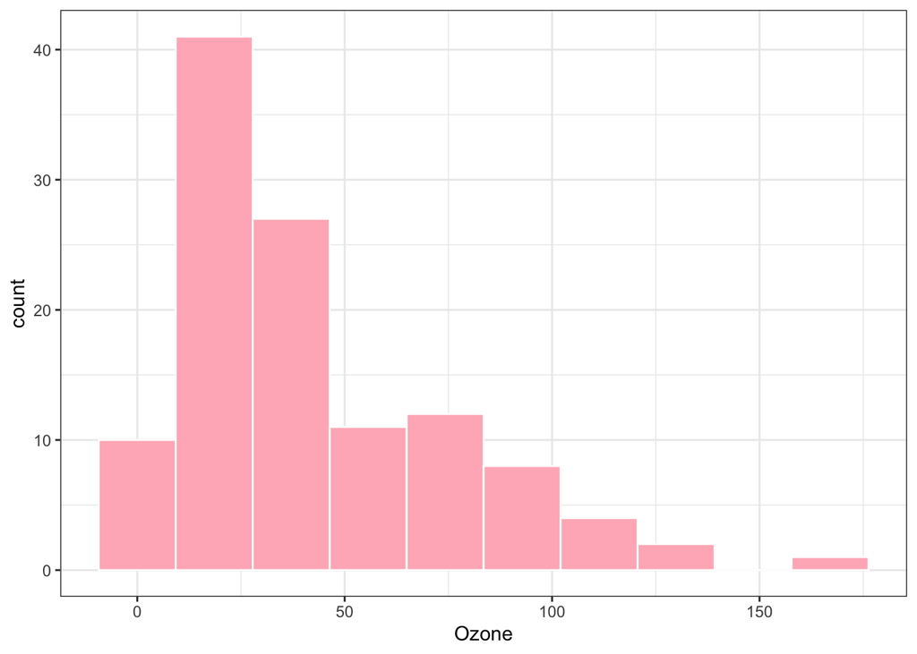

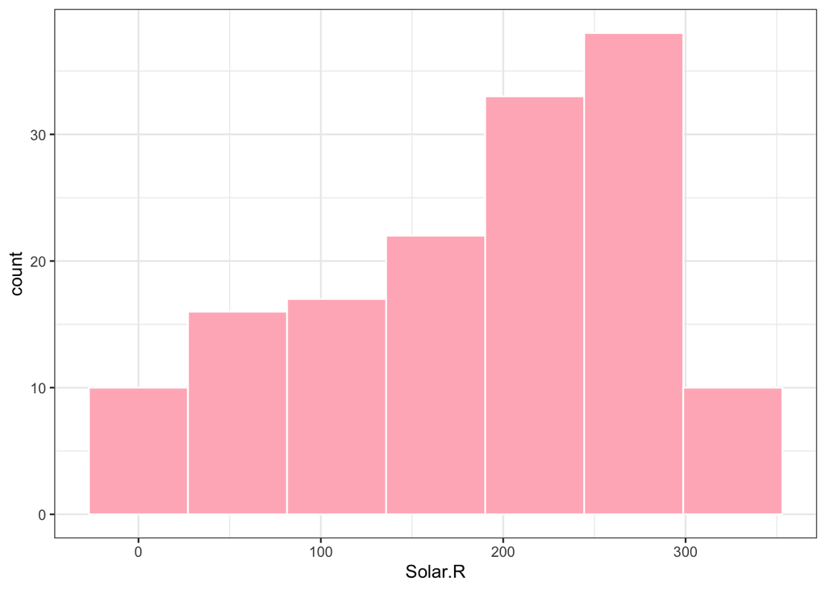

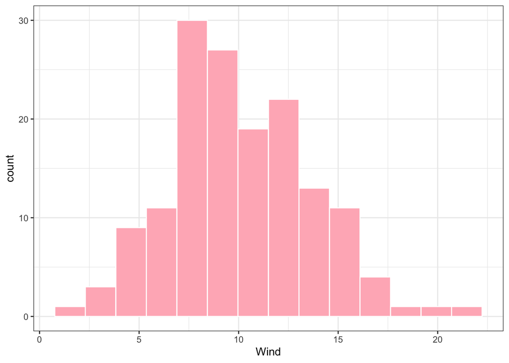

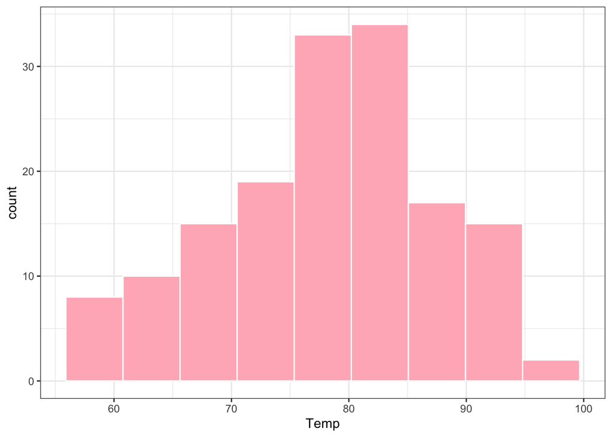

```r
#create a function to plot histogram
histogram <- function(data, var) {
  library(ggplot2); library(magrittr); library(rlang)
  theme_set(theme_bw())

  plot <- ggplot(data, aes(x = .data[[var]])) +
    geom_histogram(color = "white", fill = "lightpink",
                   binwidth = function(x) 2 * IQR(x)/
                     length(x)^(1/3))
  return(plot)
}

# extract only numerical valuables
airquality_num <- df %>% select(Ozone:Temp)

# plot histograms
histograms <-
map2(.x = list(airquality_num),
     .y = names(airquality_num),
     .f = histogram)

histograms
```

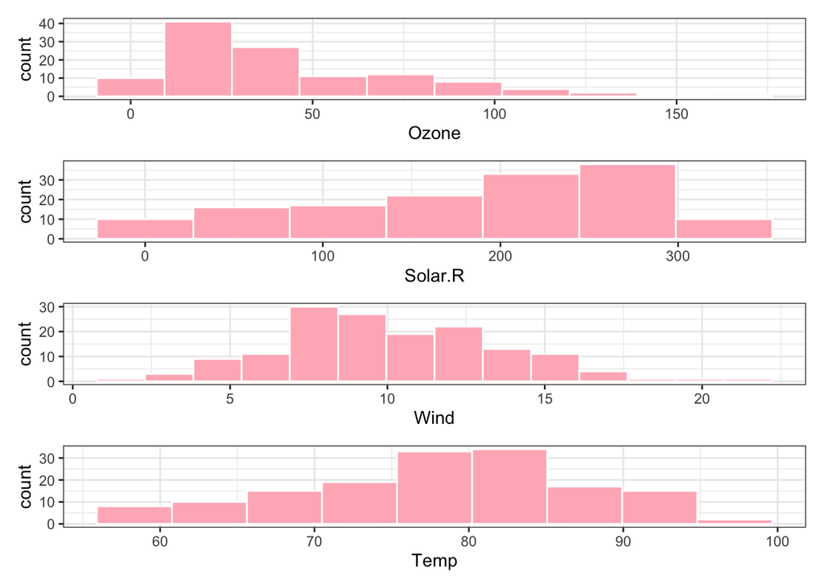

```r
#combine all plots together
wrap_plots(histograms) +
  plot_layout(nrow = length(histograms))
```

## 2.2 P2.2. Ozone by Continuous variables

- Now, let’s examine the relationship between each continuous variable and Ozone at one pair at a time. Which plot should you use and why? Also, add a regression line on the plot.  
  Choice of Plot: Scatter plots are chosen because they visually represent the relationship between two continuous variables effectively. They allow you to see patterns, correlations, and potential outliers.

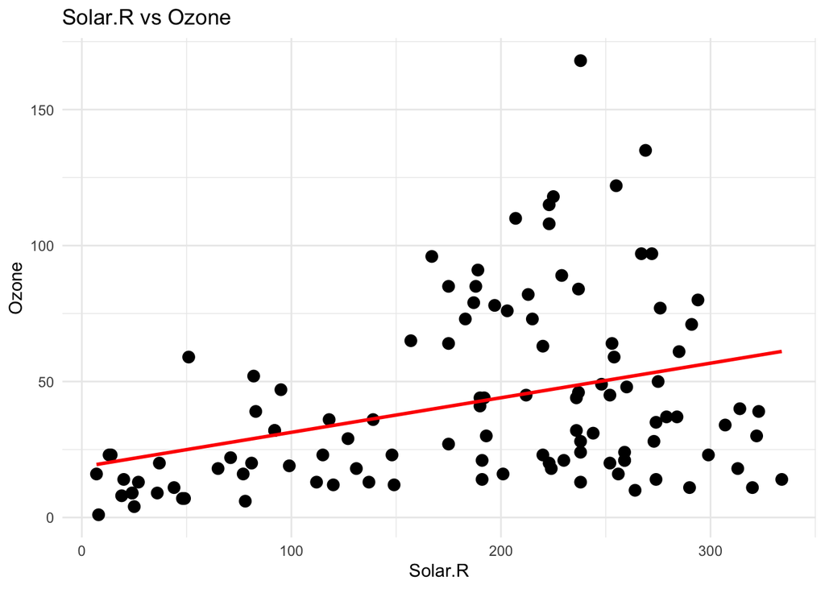

```r
#create a function to draw Ozone with different continuous variables
plot_Ozone_continuous <- function(data, var) {
  library(ggplot2)
  library(stringr)

  plot <- df %>%
    filter(!is.na(Ozone), !is.na(.data[[var]])) %>%
    ggplot(aes(x = .data[[var]], y = Ozone)) +
    geom_point(size = 3) +
    geom_smooth(formula = 'y ~ x', method = "lm",
              se = FALSE, color = "red") +
    labs(title = paste(var, "vs Ozone"),
         x = var,
         y = "Ozone") +
    theme_minimal()
  return(plot)
}

#Solar.R vs. Ozone
plot_Ozone_continuous(df, "Solar.R")
```

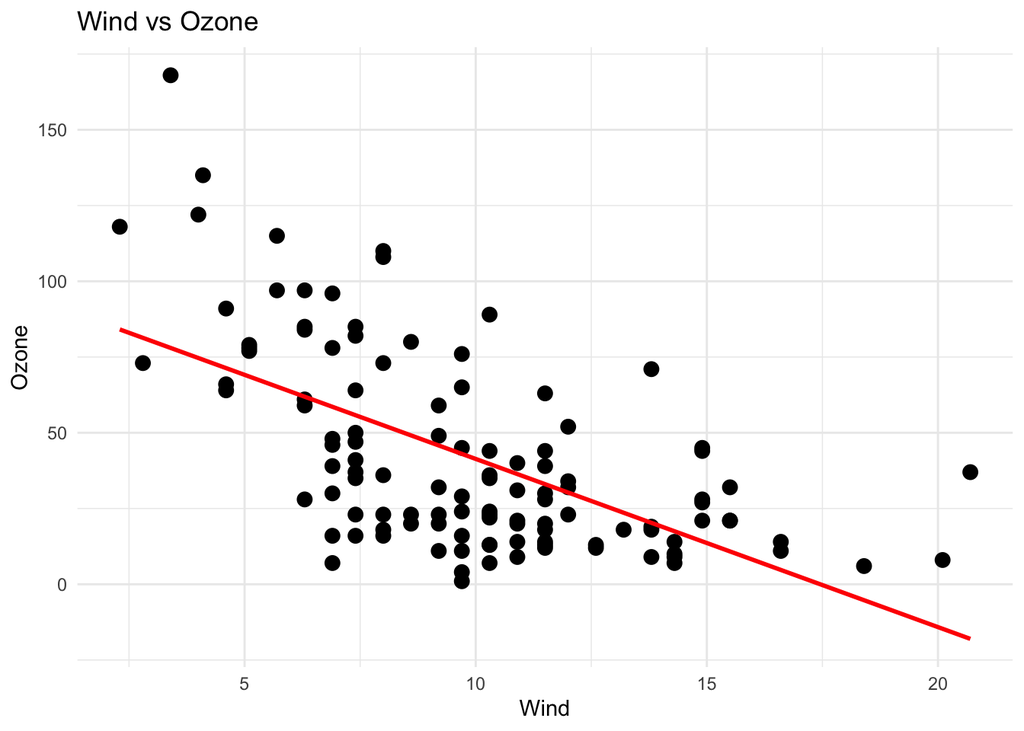

```r
#Wind vs. Ozone
plot_Ozone_continuous(df, "Wind")
```

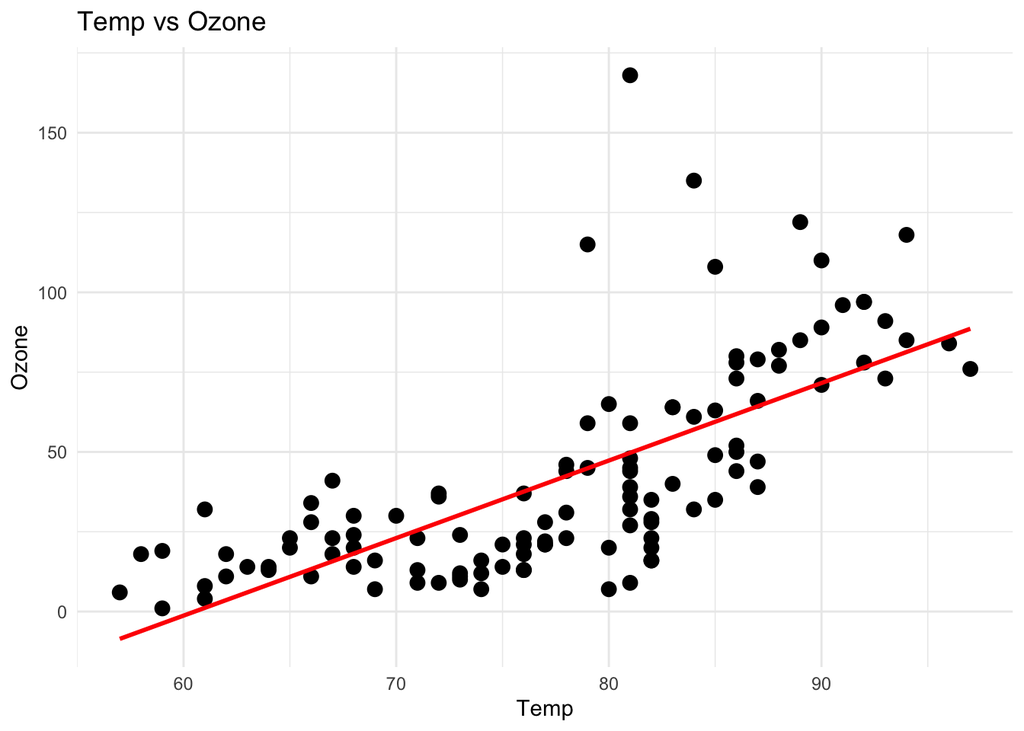

```r
#Temp vs. Ozone
plot_Ozone_continuous(df, "Temp")
```

## 2.3 P2.3. Ozone by Month (Monthly ozone amount)

- This time, draw a chart showing the impact of the categorical independent variables on the ozone amount.

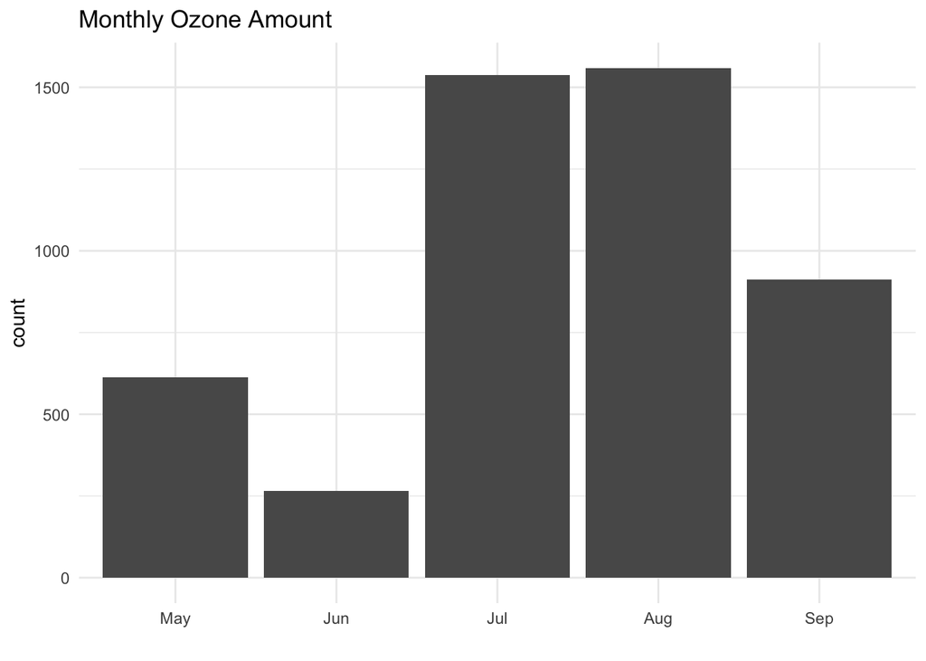

```r
df %>%
  filter(!is.na(Ozone)) %>%
  group_by(Month) %>%
  summarise(count = sum(Ozone))%>%
  ggplot(aes(x = Month, y = count)) +
  geom_col() +
  labs(title = "Monthly Ozone Amount",
       x = "") +
  theme_minimal()
```

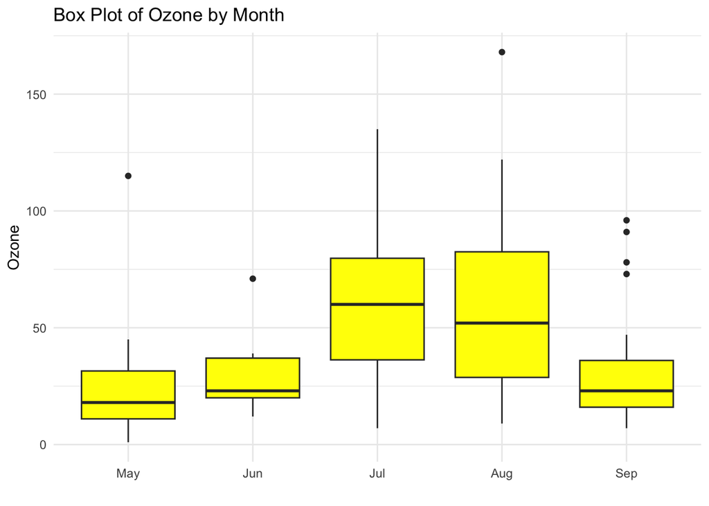

```r
df %>%
  filter(!is.na(Ozone)) %>%
  ggplot(aes(x = Month, y = Ozone)) +
  geom_boxplot(fill = "yellow") +
  labs(title = "Box Plot of Ozone by Month",
       x = "",
       y = "Ozone") +
  theme_minimal()
```

# 3 Problem 3: The moderating role of the Month?

## 3.1 P3.1. Using group_by() and summarise(), find out how many cases exist for each month.

```r
df %>%
  group_by(Month) %>%
  summarise(case = n())
```

```
## # A tibble: 5 × 2
##   Month  case
##   <fct> <int>
## 1 May      31
## 2 Jun      30
## 3 Jul      31
## 4 Aug      31
## 5 Sep      30
```

## 3.2 P3.2. Draw a series of charts showing the impact of Solar.R on Ozone cut by Month.

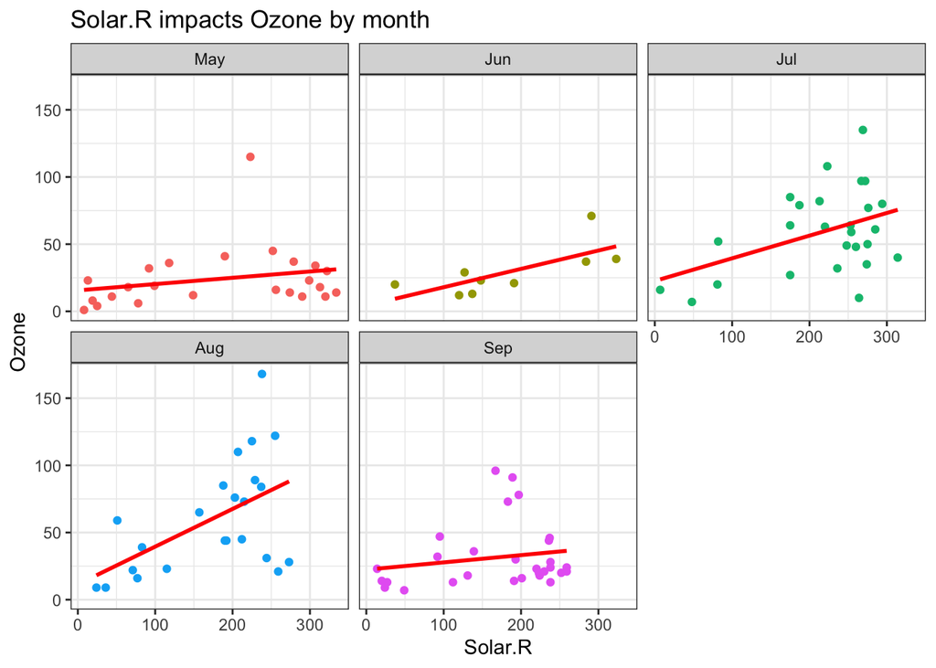

```r
#create a function to draw different variables' impact on Ozone cut by month
plot_Ozone_continuous_monthly <- function(data, var) {
  library(ggplot2)
  library(stringr)
  theme_set(theme_bw())

  plot <- ggplot(df, aes(x = .data[[var]], y = Ozone, color = Month)) +
    geom_point(show.legend = FALSE) +
    geom_smooth(color = "red", formula = 'y ~ x',
                method = "lm", se = FALSE) +
    facet_wrap(~Month) +
    labs(title = paste(var, "impacts Ozone by month"),
         x = var,
         y = "Ozone")
  return(plot)
}

#apply function with Solar.R
plot_Ozone_continuous_monthly(df, "Solar.R")
```

## 3.3 P3.3. Draw a series of charts showing the impact of Wind on Ozone cut by Month.

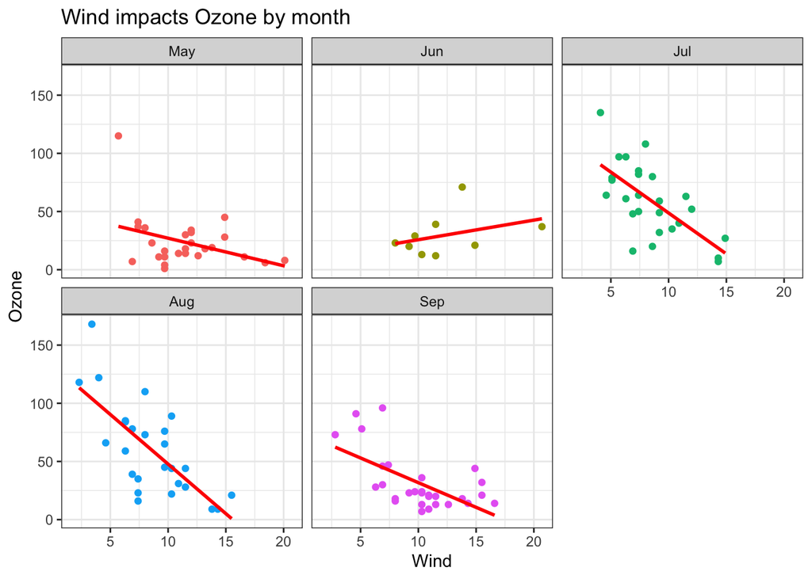

```r
plot_Ozone_continuous_monthly(df, "Wind")
```

## 3.4 P3.4. Draw a series of charts showing the impact of Temp on Ozone cut by Month.

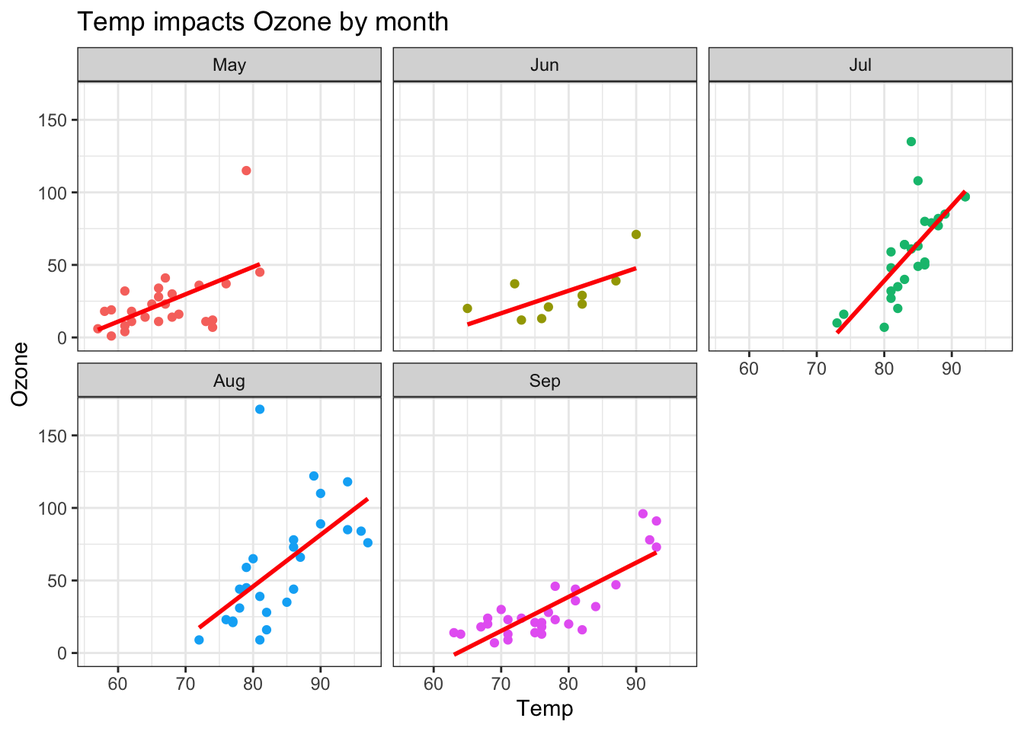

```r
plot_Ozone_continuous_monthly(df, "Temp")
```

## 3.5 P3.5 Based on the descriptive statistics above, can you conclude that the impact of Solar.R and Wind on Ozone changes by Month?

- Solar.R impact: Each month’s plot shows a trend where Ozone increases with Solar.R, indicating that more solar radiation contributes to higher ozone levels.
- Wind impact: Wind appears to have a more complex and less direct impact on ozone levels. High wind speeds might reduce Ozone concentrations by dispersing pollutants, but this effect can vary depending on other atmospheric conditions.

# 4 Problem 4: Correlations

## 4.1 P4.1. The data visualization so far should have helped you form associations among the variables. Now, let’s try to quantify the associations by running correlations among all numeric variables.

```r
df %>% select(Ozone:Temp) %>% cor(use = "pairwise.complete.obs")
```

```
##              Ozone     Solar.R        Wind       Temp
## Ozone    1.0000000  0.34834169 -0.60154653  0.6983603
## Solar.R  0.3483417  1.00000000 -0.05679167  0.2758403
## Wind    -0.6015465 -0.05679167  1.00000000 -0.4579879
## Temp     0.6983603  0.27584027 -0.45798788  1.0000000
```

## 4.2 P4.2. Which variables are correlated highly with Ozone? Describe the nature of the association – whether the association is positive or negative, strongly or weakly correlated.

# 5 Problem 5: Examine Missing values

When you ran simple descriptive statistics previously, you would have noticed that two variables had missing values, which might have given you some trouble while you visualized the data.

Write the codes that tell you (1)where the missing values are located,

```r
df %>% is.na()
```

```
##        Ozone Solar.R  Wind  Temp Month   Day
##   [1,] FALSE   FALSE FALSE FALSE FALSE FALSE
##   [2,] FALSE   FALSE FALSE FALSE FALSE FALSE
##   [3,] FALSE   FALSE FALSE FALSE FALSE FALSE
##   [4,] FALSE   FALSE FALSE FALSE FALSE FALSE
##   [5,]  TRUE    TRUE FALSE FALSE FALSE FALSE
##   [6,] FALSE    TRUE FALSE FALSE FALSE FALSE
##   [7,] FALSE   FALSE FALSE FALSE FALSE FALSE
##   [8,] FALSE   FALSE FALSE FALSE FALSE FALSE
##   [9,] FALSE   FALSE FALSE FALSE FALSE FALSE
##  [10,]  TRUE   FALSE FALSE FALSE FALSE FALSE
##  [11,] FALSE    TRUE FALSE FALSE FALSE FALSE
##  [12,] FALSE   FALSE FALSE FALSE FALSE FALSE
##  [13,] FALSE   FALSE FALSE FALSE FALSE FALSE
##  [14,] FALSE   FALSE FALSE FALSE FALSE FALSE
```

[output cut: 139 more lines]

2. the number of missing values in the dataset (df),

```r
df %>% summarise_all(~sum(is.na(.)))
```

```
## # A tibble: 1 × 6
##   Ozone Solar.R  Wind  Temp Month   Day
##   <int>   <int> <int> <int> <int> <int>
## 1    37       7     0     0     0     0
```

3. the number of missing values in the Solar.R column, and

```r
df %>% select(Solar.R) %>%
  filter(is.na(Solar.R)) %>% count()
```

```
## # A tibble: 1 × 1
##       n
##   <int>
## 1     7
```

```r
#or
df %>% summarise_all(~sum(is.na(.))) %>% select(Solar.R)
```

```
## # A tibble: 1 × 1
##   Solar.R
##     <int>
## 1       7
```

```r
#or
sum(is.na(df['Solar.R']))
```

```
## [1] 7
```

4. all the rows that include at least one missing value.

```r
df_na <- df %>% filter(if_any(everything(), is.na))

df_na
```

```
## # A tibble: 42 × 6
##    Ozone Solar.R  Wind  Temp Month   Day
##    <int>   <int> <dbl> <int> <fct> <int>
##  1    NA      NA  14.3    56 May       5
##  2    28      NA  14.9    66 May       6
##  3    NA     194   8.6    69 May      10
##  4     7      NA   6.9    74 May      11
##  5    NA      66  16.6    57 May      25
##  6    NA     266  14.9    58 May      26
##  7    NA      NA   8      57 May      27
##  8    NA     286   8.6    78 Jun       1
##  9    NA     287   9.7    74 Jun       2
## 10    NA     242  16.1    67 Jun       3
## # ℹ 32 more rows
```

5. Lastly, write the code that returns the number of rows with at least one missing value. Hint: some rows have more than one missing value.

```r
nrow(df_na)
```

```
## [1] 42
```

# 6 Problem 6: Missing value imputation

1. Replace all the missing values in the Solar.R column with the median of the values in the column.

```r
Solar_median<- df %>%
  filter(!is.na(Solar.R)) %>%
  summarise(Solar_median = median(Solar.R))
print(Solar_median)
```

```
## # A tibble: 1 × 1
##   Solar_median
##          <dbl>
## 1          205
```

```r
df['Solar.R'][is.na(df['Solar.R'])] <- as.integer(Solar_median)
df
```

```
## # A tibble: 153 × 6
##    Ozone Solar.R  Wind  Temp Month   Day
##    <int>   <int> <dbl> <int> <fct> <int>
##  1    41     190   7.4    67 May       1
##  2    36     118   8      72 May       2
##  3    12     149  12.6    74 May       3
##  4    18     313  11.5    62 May       4
##  5    NA     205  14.3    56 May       5
##  6    28     205  14.9    66 May       6
##  7    23     299   8.6    65 May       7
##  8    19      99  13.8    59 May       8
##  9     8      19  20.1    61 May       9
## 10    NA     194   8.6    69 May      10
## # ℹ 143 more rows
```

2. Replace all the missing values in the Ozone column with the median of the values in the column.

```r
Ozone_median<- df %>%
  filter(!is.na(Ozone)) %>%
  summarise(Ozone_median = median(Ozone))
print(Ozone_median)
```

```
## # A tibble: 1 × 1
##   Ozone_median
##          <dbl>
## 1         31.5
```

```r
df['Ozone'][is.na(df['Ozone'])] <- as.integer(Ozone_median)
df
```

```
## # A tibble: 153 × 6
##    Ozone Solar.R  Wind  Temp Month   Day
##    <int>   <int> <dbl> <int> <fct> <int>
##  1    41     190   7.4    67 May       1
##  2    36     118   8      72 May       2
##  3    12     149  12.6    74 May       3
##  4    18     313  11.5    62 May       4
##  5    31     205  14.3    56 May       5
##  6    28     205  14.9    66 May       6
##  7    23     299   8.6    65 May       7
##  8    19      99  13.8    59 May       8
##  9     8      19  20.1    61 May       9
## 10    31     194   8.6    69 May      10
## # ℹ 143 more rows
```

3. Take a look at the descriptive statistics again.

```r
summary(df)
```

```
##      Ozone           Solar.R           Wind             Temp       Month
##  Min.   :  1.00   Min.   :  7.0   Min.   : 1.700   Min.   :56.00   May:31
##  1st Qu.: 21.00   1st Qu.:120.0   1st Qu.: 7.400   1st Qu.:72.00   Jun:30
##  Median : 31.00   Median :205.0   Median : 9.700   Median :79.00   Jul:31
##  Mean   : 39.44   Mean   :186.8   Mean   : 9.958   Mean   :77.88   Aug:31
##  3rd Qu.: 46.00   3rd Qu.:256.0   3rd Qu.:11.500   3rd Qu.:85.00   Sep:30
##  Max.   :168.00   Max.   :334.0   Max.   :20.700   Max.   :97.00
##       Day
##  Min.   : 1.0
##  1st Qu.: 8.0
##  Median :16.0
##  Mean   :15.8
##  3rd Qu.:23.0
##  Max.   :31.0
```

4. Also, get the mean and standard deviation of all continuous variables.

```r
df %>%
  summarize(across(c(Ozone:Temp),
                   list(Mean = mean, SD = sd),
                   .names = "{.col}_{.fn}")
            )
```

```
## # A tibble: 1 × 8
##   Ozone_Mean Ozone_SD Solar.R_Mean Solar.R_SD Wind_Mean Wind_SD Temp_Mean
##        <dbl>    <dbl>        <dbl>      <dbl>     <dbl>   <dbl>     <dbl>
## 1       39.4     29.1         187.       88.1      9.96    3.52      77.9
## # ℹ 1 more variable: Temp_SD <dbl>
```

# 7 Problem 7: Correlations after missing value imputation

## 7.1 P7.1. Correlation with raw Ozone

- Run the correlation analysis you did in Problem 4 again.

```r
df %>% select(Ozone:Temp) %>% cor(use = "pairwise.complete.obs")
```

```
##              Ozone     Solar.R        Wind       Temp
## Ozone    1.0000000  0.29495314 -0.53162566  0.6001034
## Solar.R  0.2949531  1.00000000 -0.05789854  0.2571538
## Wind    -0.5316257 -0.05789854  1.00000000 -0.4579879
## Temp     0.6001034  0.25715377 -0.45798788  1.0000000
```

## 7.2 P7.2. Correlations with Logged Ozone

- This time, create a new variable by taking the log of Ozone – log(Ozone) – as Ozone is severely skewed. Write the code to repeat (1) with the log-transformed form of Ozone.

```r
df %>%
  mutate(Ozone_logged = log(Ozone)) %>%
  select(-Month, -Day) %>%
  cor(use = "pairwise.complete.obs")
```

```
##                   Ozone     Solar.R        Wind       Temp Ozone_logged
## Ozone         1.0000000  0.29495314 -0.53162566  0.6001034    0.8794206
## Solar.R       0.2949531  1.00000000 -0.05789854  0.2571538    0.3937871
## Wind         -0.5316257 -0.05789854  1.00000000 -0.4579879   -0.4747741
## Temp          0.6001034  0.25715377 -0.45798788  1.0000000    0.6448765
## Ozone_logged  0.8794206  0.39378709 -0.47477406  0.6448765    1.0000000
```

- What can you tell about the strength of association between the transformed Ozone and the other three variables? Do you see a pattern of relationships that differ in the two sets of correlations? Why do you think there were discrepancies?

# 8 Problem 8: Adding a new variable to the data sets and adjusting data types

1. Since the logged Ozone variable seems to be helpful, let’s add the variable.
2. Look for the unique value of the Month variable. Since Month is categorical data, change it to a factor data type in preparation for visualization
3. Also, change the data type to tibble permanently.
4. Confirm that the changes you made are successful by printing out the data sets.

```r
#add log(Ozone) to df
df<- df %>%
  mutate(Ozone_logged = log(Ozone))
df
```

```
## # A tibble: 153 × 7
##    Ozone Solar.R  Wind  Temp Month   Day Ozone_logged
##    <int>   <int> <dbl> <int> <fct> <int>        <dbl>
##  1    41     190   7.4    67 May       1         3.71
##  2    36     118   8      72 May       2         3.58
##  3    12     149  12.6    74 May       3         2.48
##  4    18     313  11.5    62 May       4         2.89
##  5    31     205  14.3    56 May       5         3.43
##  6    28     205  14.9    66 May       6         3.33
##  7    23     299   8.6    65 May       7         3.14
##  8    19      99  13.8    59 May       8         2.94
##  9     8      19  20.1    61 May       9         2.08
## 10    31     194   8.6    69 May      10         3.43
## # ℹ 143 more rows
```

```r
#convert Month to factor
df$Month <- factor(df$Month)
class(df$Month)
```

```
## [1] "factor"
```

```r
#convert df to tibble
df <- as_tibble(df)
class(df)
```

```
## [1] "tbl_df"     "tbl"        "data.frame"
```

```r
df
```

```
## # A tibble: 153 × 7
##    Ozone Solar.R  Wind  Temp Month   Day Ozone_logged
##    <int>   <int> <dbl> <int> <fct> <int>        <dbl>
##  1    41     190   7.4    67 May       1         3.71
##  2    36     118   8      72 May       2         3.58
##  3    12     149  12.6    74 May       3         2.48
##  4    18     313  11.5    62 May       4         2.89
##  5    31     205  14.3    56 May       5         3.43
##  6    28     205  14.9    66 May       6         3.33
##  7    23     299   8.6    65 May       7         3.14
##  8    19      99  13.8    59 May       8         2.94
##  9     8      19  20.1    61 May       9         2.08
## 10    31     194   8.6    69 May      10         3.43
## # ℹ 143 more rows
```

# 9 Problem 9: Data Visualization using imputed data

Let’s repeat the visualization you did in Problem 2 and Problem 3, using the imputed data and Log-transformed Ozone variable. Specifically, do the following data visualizations.

## 9.1 P9.1. Histogram of Ozone, Ozone_logged, and Solar.R

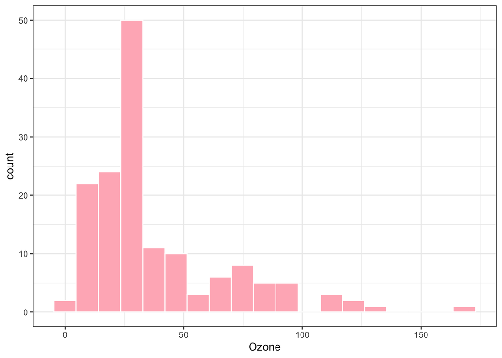

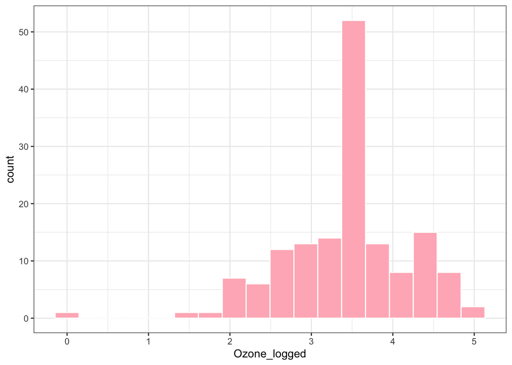

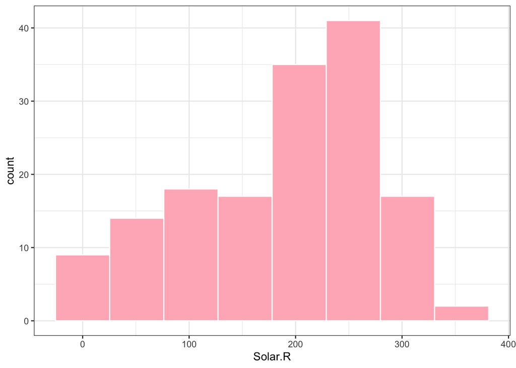

```r
# plot histograms using function created in P2
df_p9 <- df %>% select(Ozone, Ozone_logged, Solar.R)

histograms_p9 <-
map2(.x = list(df_p9),
     .y = names(df_p9),
     .f = histogram)

histograms_p9
```

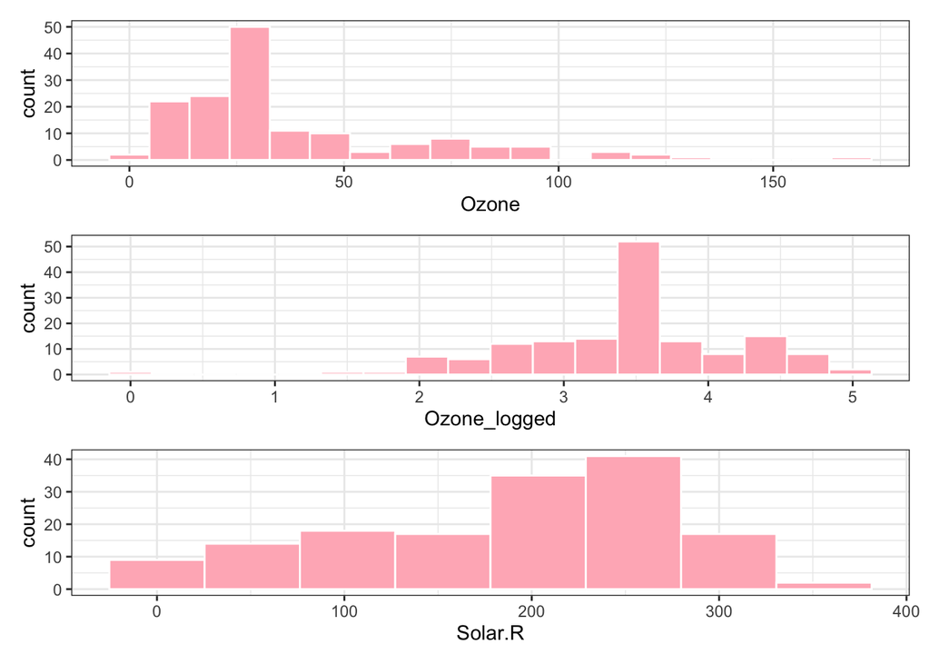

```r
#combine all plots together
wrap_plots(histograms_p9) +
  plot_layout(nrow = length(histograms_p9))
```

## 9.2 P9.2. Ozone by Continuous variables

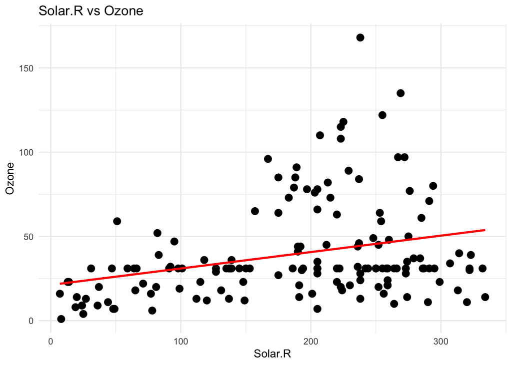

```r
#using function created in p2.2
#Solar.R vs. Ozone
plot_Ozone_continuous(df, "Solar.R")
```

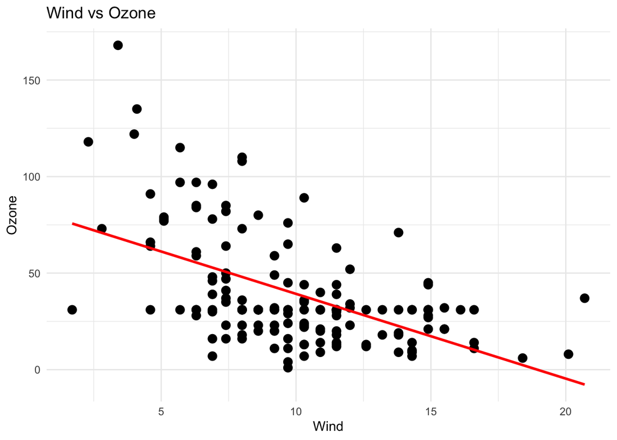

```r
#Wind vs. Ozone
plot_Ozone_continuous(df, "Wind")
```

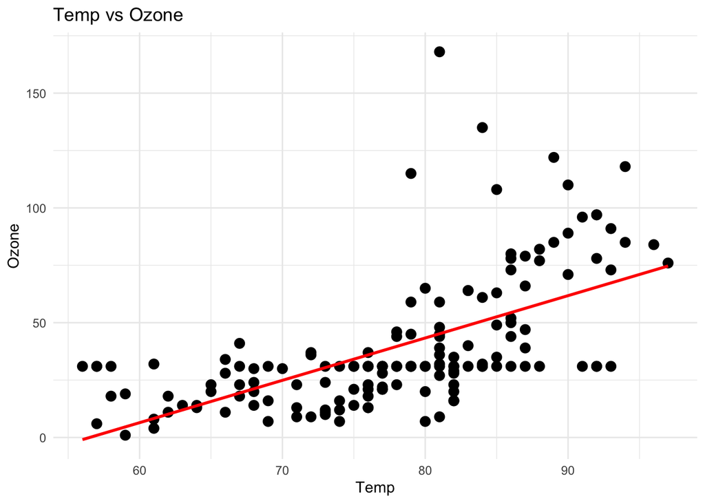

```r
#Temp vs. Ozone
plot_Ozone_continuous(df, "Temp")
```

## P9.3. Ozone by Month

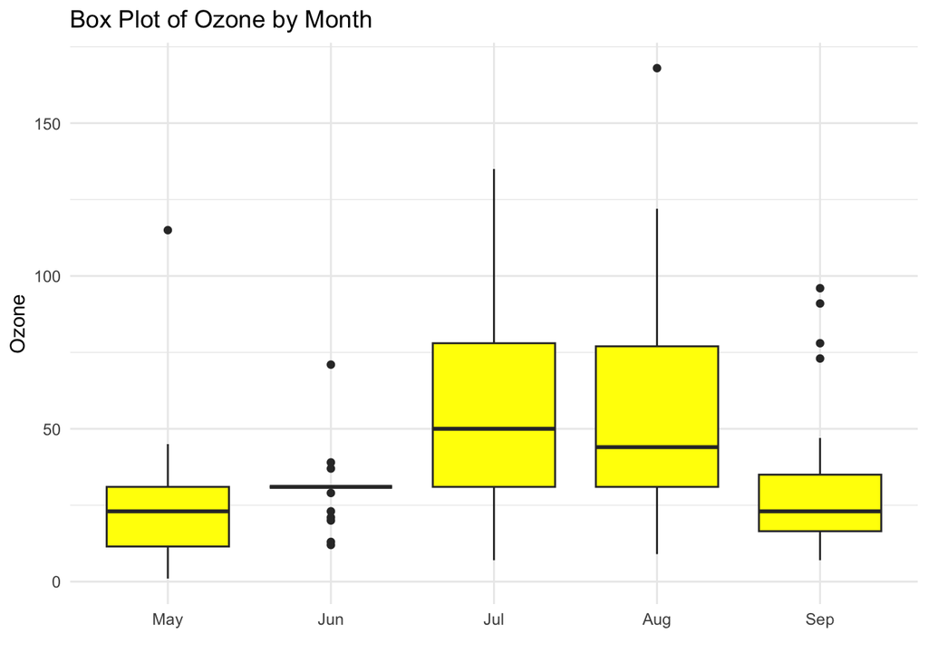

```r
df %>%
  ggplot(aes(x = Month, y = Ozone)) +
  geom_boxplot(fill = "yellow") +
  labs(title = "Box Plot of Ozone by Month",
       x = "",
       y = "Ozone") +
  theme_minimal()
```

## P9.4. Moderating Role of Month in the impact of Continuous variables on Ozone

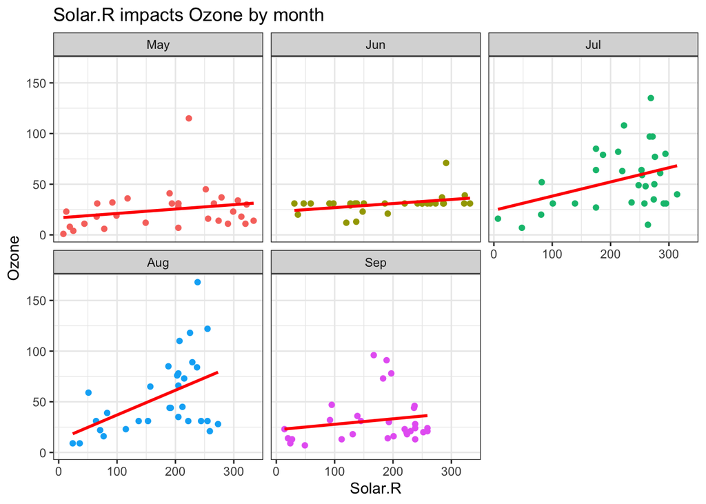

```r
#using function created in 3.2
#Solar.R impacts on Ozone
plot_Ozone_continuous_monthly(df, "Solar.R")
```

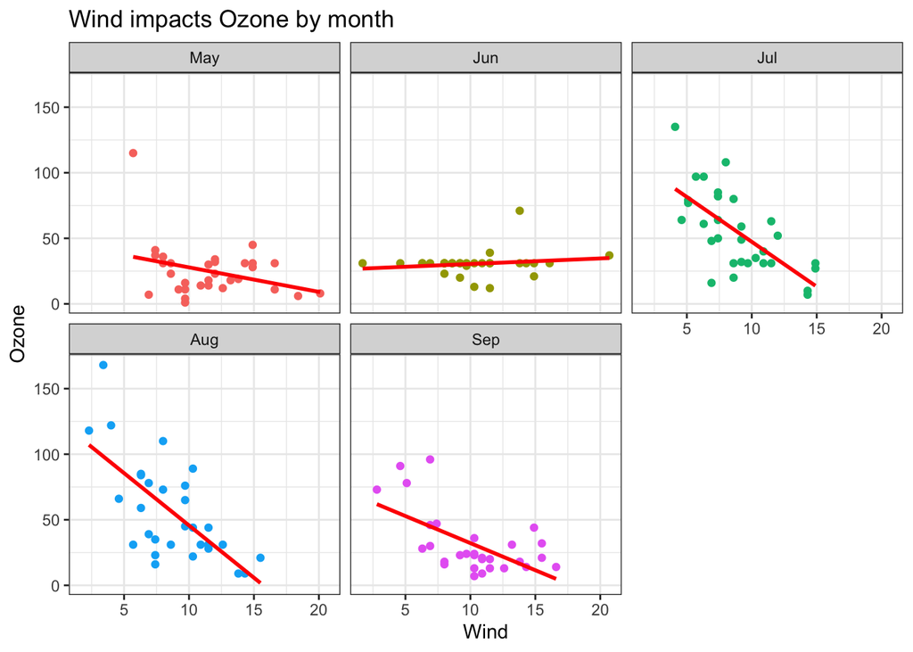

```r
#Wind impacts on Ozone
plot_Ozone_continuous_monthly(df, "Wind")
```

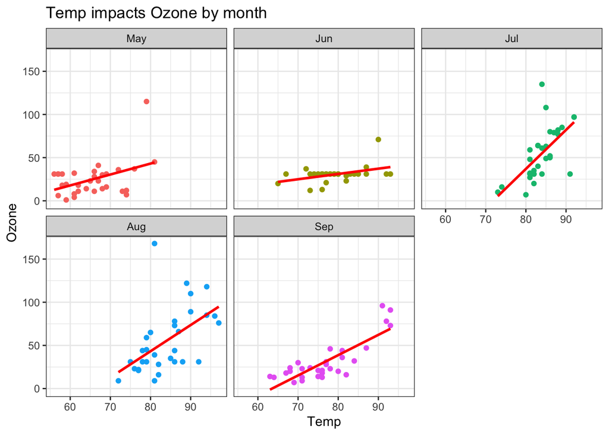

```r
#Temp impacts on Ozone
plot_Ozone_continuous_monthly(df, "Temp")
```

## P9.5: Do you find the same relationships as before?

- Yes, most of the impacts show on the plots for each month remain the same as before, except for June. The denser alignment of points and the smoother fit line for June indicate that imputation had a significant effect on the data distribution for that month. This suggests that the missing values in June were numerous and replacing them with summary statistics of median altered the overall distribution of the data.